# ESCUELA POLITECNICA NACIONAL

# INGENIERIA EN CIENCIAS DE LA COMPUTACION

# Data Mining y Machine Learning

## 2 Hands On: Data Quality and Pre-Processing

### GR2CC_2023-1

# 1. Assessing Data Quality

## Load the following packages: dplyr, na.tools, tidyimpute (version from github decisionpatterns/tidyimpute”)

## Load the carInsurance data set about the insurance risk rating of cars based on several characteristics of each car1

### (a) Check if there are any missing values. (Compruebe si faltan valores)

```r
library(dplyr)
library(na.tools)
library(tidyimpute)
library(tidyverse)
# Carga el archivo .Rdata
df <- load("R:\\Politécnica.Nacional\\2023-A\\Data Mining\\Deberes.Data\\carInsurance.Rdata")

# Obtiene y verifica los objetos cargados en el entorno
#ls()
carIns
```

| symb | normLoss | make | fuelType | aspiration | nDoors | bodyStyle | driveWheels | engineLocation | wheelBase | length | width | height | curbWeight | engineType | nrCylinds | engineSize | fuelSystem | bore | stroke | compressionRatio | horsePower | peakRpm | cityMpg | highwayMpg | price |
| --- | --- | --- | --- | --- | --- | --- | --- | --- | --- | --- | --- | --- | --- | --- | --- | --- | --- | --- | --- | --- | --- | --- | --- | --- | --- |
| 3 | NA | alfa-romero | gas | std | two | convertible | rwd | front | 88.6 | 168.8 | 64.1 | 48.8 | 2548 | dohc | four | 130 | mpfi | 3.47 | 2.68 | 9.00 | 111 | 5000 | 21 | 27 | 13495 |
| 3 | NA | alfa-romero | gas | std | two | convertible | rwd | front | 88.6 | 168.8 | 64.1 | 48.8 | 2548 | dohc | four | 130 | mpfi | 3.47 | 2.68 | 9.00 | 111 | 5000 | 21 | 27 | 16500 |
| 1 | NA | alfa-romero | gas | std | two | hatchback | rwd | front | 94.5 | 171.2 | 65.5 | 52.4 | 2823 | ohcv | six | 152 | mpfi | 2.68 | 3.47 | 9.00 | 154 | 5000 | 19 | 26 | 16500 |
| 2 | 164 | audi | gas | std | four | sedan | fwd | front | 99.8 | 176.6 | 66.2 | 54.3 | 2337 | ohc | four | 109 | mpfi | 3.19 | 3.40 | 10.00 | 102 | 5500 | 24 | 30 | 13950 |
| 2 | 164 | audi | gas | std | four | sedan | 4wd | front | 99.4 | 176.6 | 66.4 | 54.3 | 2824 | ohc | five | 136 | mpfi | 3.19 | 3.40 | 8.00 | 115 | 5500 | 18 | 22 | 17450 |
| 2 | NA | audi | gas | std | two | sedan | fwd | front | 99.8 | 177.3 | 66.3 | 53.1 | 2507 | ohc | five | 136 | mpfi | 3.19 | 3.40 | 8.50 | 110 | 5500 | 19 | 25 | 15250 |
| 1 | 158 | audi | gas | std | four | sedan | fwd | front | 105.8 | 192.7 | 71.4 | 55.7 | 2844 | ohc | five | 136 | mpfi | 3.19 | 3.40 | 8.50 | 110 | 5500 | 19 | 25 | 17710 |
| 1 | NA | audi | gas | std | four | wagon | fwd | front | 105.8 | 192.7 | 71.4 | 55.7 | 2954 | ohc | five | 136 | mpfi | 3.19 | 3.40 | 8.50 | 110 | 5500 | 19 | 25 | 18920 |
| 1 | 158 | audi | gas | turbo | four | sedan | fwd | front | 105.8 | 192.7 | 71.4 | 55.9 | 3086 | ohc | five | 131 | mpfi | 3.13 | 3.40 | 8.30 | 140 | 5500 | 17 | 20 | 23875 |
| 0 | NA | audi | gas | turbo | two | hatchback | 4wd | front | 99.5 | 178.2 | 67.9 | 52.0 | 3053 | ohc | five | 131 | mpfi | 3.13 | 3.40 | 7.00 | 160 | 5500 | 16 | 22 | NA |

[output cut: 195 more lines]

```r
# Verifica si hay valores faltantes
if(any_na(carIns)){
  print("Existe valores faltantes en el objeto 'carIns'")
} else{
  print("No esxiste valores faltantes en el objeto 'carIns")
}
```

```
## [1] "Existe valores faltantes en el objeto 'carIns'"
```

### (b) Cuente el número de casos que tienen, al menos, un valor faltante.

```r
# Filtrar los casos con al menos un valor faltante
casosFaltantes <- carIns %>% filter_any_na()

# Numero de casos con numeros faltantes
numCasosFaltantes <- casosFaltantes %>% count()

# Imprime el numero de casos faltantes
print(numCasosFaltantes)
```

[output not shown]

### (c) Cree un nuevo conjunto de datos eliminando todos los casos que tengan valores faltantes.

```r
# Crea un nuevo conjunto de datos eliminando las filas que con valores faltantes
nuevo_df <- drop_rows_any_na(carIns)

print(nuevo_df)
```

```
## # A tibble: 159 × 26
##     symb normLoss make      fuelType aspiration nDoors bodyStyle driveWheels
##    <int>    <int> <fct>     <fct>    <fct>      <fct>  <fct>     <fct>
##  1     2      164 audi      gas      std        four   sedan     fwd
##  2     2      164 audi      gas      std        four   sedan     4wd
##  3     1      158 audi      gas      std        four   sedan     fwd
##  4     1      158 audi      gas      turbo      four   sedan     fwd
##  5     2      192 bmw       gas      std        two    sedan     rwd
##  6     0      192 bmw       gas      std        four   sedan     rwd
##  7     0      188 bmw       gas      std        two    sedan     rwd
##  8     0      188 bmw       gas      std        four   sedan     rwd
##  9     2      121 chevrolet gas      std        two    hatchback fwd
## 10     1       98 chevrolet gas      std        two    hatchback fwd
## # ℹ 149 more rows
## # ℹ 18 more variables: engineLocation <fct>, wheelBase <dbl>, length <dbl>,
## #   width <dbl>, height <dbl>, curbWeight <int>, engineType <fct>,
## #   nrCylinds <fct>, engineSize <int>, fuelSystem <fct>, bore <dbl>,
## #   stroke <dbl>, compressionRatio <dbl>, horsePower <int>, peakRpm <int>,
## #   cityMpg <int>, highwayMpg <int>, price <int>
```

### (d) Cree un nuevo conjunto de datos ingresando todos los valores faltantes con 0.

Consejo: explore las variantes de la función impute()

```r
# Convertir el objeto en un dataframe
df <- as.data.frame(carIns)

# Recorrer las columnas del dataframe
for (col in names(df)) {
  # Reemplazar los valores faltantes por ceros en cada columna
  df[is.na(df[, col]), col] <- 0
}
# Imprimir el dataframe con los valores faltantes reemplazados por 0
print(df)
```

```
##     symb normLoss          make fuelType aspiration nDoors   bodyStyle
## 1      3        0   alfa-romero      gas        std    two convertible
## 2      3        0   alfa-romero      gas        std    two convertible
## 3      1        0   alfa-romero      gas        std    two   hatchback
## 4      2      164          audi      gas        std   four       sedan
## 5      2      164          audi      gas        std   four       sedan
## 6      2        0          audi      gas        std    two       sedan
## 7      1      158          audi      gas        std   four       sedan
## 8      1        0          audi      gas        std   four       wagon
## 9      1      158          audi      gas      turbo   four       sedan
## 10     0        0          audi      gas      turbo    two   hatchback
## 11     2      192           bmw      gas        std    two       sedan
## 12     0      192           bmw      gas        std   four       sedan
## 13     0      188           bmw      gas        std    two       sedan
## 14     0      188           bmw      gas        std   four       sedan
```

[output cut: 809 more lines]

### (e) Cree un nuevo conjunto de datos imputando la media en todas las columnas que tengan valores de tipo double.

```r
# Convertir el objeto en un dataframe
df <- as.data.frame(carIns)

# Calcula la Media e imputa en todas las columnas de tipo double
dataMedia <- df %>%
  mutate_if(is.double, ~ ifelse(is.na(.), mean(., na.rm = TRUE), .))
# mutate_if realiza cambios condicionales en las columnas de acuerdo a una condicion especifica
#is.double funcion que devuelve TRUE para las columnas que cumplan la condicion de tipo double

# Imprime el conjunto de datos
print(dataMedia)
```

```
##     symb normLoss          make fuelType aspiration nDoors   bodyStyle
## 1      3       NA   alfa-romero      gas        std    two convertible
## 2      3       NA   alfa-romero      gas        std    two convertible
## 3      1       NA   alfa-romero      gas        std    two   hatchback
## 4      2      164          audi      gas        std   four       sedan
## 5      2      164          audi      gas        std   four       sedan
## 6      2       NA          audi      gas        std    two       sedan
## 7      1      158          audi      gas        std   four       sedan
## 8      1       NA          audi      gas        std   four       wagon
## 9      1      158          audi      gas      turbo   four       sedan
## 10     0       NA          audi      gas      turbo    two   hatchback
## 11     2      192           bmw      gas        std    two       sedan
## 12     0      192           bmw      gas        std   four       sedan
## 13     0      188           bmw      gas        std    two       sedan
## 14     0      188           bmw      gas        std   four       sedan
```

[output cut: 809 more lines]

### (f) Cree un nuevo conjunto de datos ingresando la moda en todas las columnas que tienen valores de tipo entero.

```r
# Convertir el objeto en un dataframe
df <- as.data.frame(carIns)

# Función para calcular la moda
calculate_mode <- function(x) {
  mod <- as.data.frame(table(x))
  mod <- mod[which.max(mod$Freq), 1]
  return(mod)
}

# Calcula la Moda de las columnas numericas de un dataframe y reemplaza los valores NA por la moda correspondiente a cada columna
dataModa <- df %>%
  mutate(across(where(is.numeric), ~ ifelse(is.na(.), calculate_mode(.), .)))
# across selecciona las columnas que cumplen una determinada condicion, en nuestro caso las columnas numericas


# Imprime el nuevo conjunto de datos
print(dataModa)
```

```
##     symb normLoss          make fuelType aspiration nDoors   bodyStyle
## 1      3       42   alfa-romero      gas        std    two convertible
## 2      3       42   alfa-romero      gas        std    two convertible
## 3      1       42   alfa-romero      gas        std    two   hatchback
## 4      2      164          audi      gas        std   four       sedan
## 5      2      164          audi      gas        std   four       sedan
## 6      2       42          audi      gas        std    two       sedan
## 7      1      158          audi      gas        std   four       sedan
## 8      1       42          audi      gas        std   four       wagon
## 9      1      158          audi      gas      turbo   four       sedan
## 10     0       42          audi      gas      turbo    two   hatchback
## 11     2      192           bmw      gas        std    two       sedan
## 12     0      192           bmw      gas        std   four       sedan
## 13     0      188           bmw      gas        std    two       sedan
## 14     0      188           bmw      gas        std   four       sedan
```

[output cut: 809 more lines]

### (g) Cree un nuevo conjunto de datos imputando el valor más frecuente a la columna “nDoors”. Sugerencia: utilice la función impute_replace()

```r
# Crea una copia del dataframe cargado
dfValFrecuente <- df

# Calcula la moda de la columna "nDoors"
modaNdoors <- calculate_mode(dfValFrecuente$nDoors)

# Reemplaza los valores NA de la columna nDoors con la moda calculada
dfValFrecuente <- dfValFrecuente %>%
  mutate(nDoors = replace_na(nDoors, modaNdoors))

# Imprime el nuevo dataframe
print(dfValFrecuente)
```

```
##     symb normLoss          make fuelType aspiration nDoors   bodyStyle
## 1      3       NA   alfa-romero      gas        std    two convertible
## 2      3       NA   alfa-romero      gas        std    two convertible
## 3      1       NA   alfa-romero      gas        std    two   hatchback
## 4      2      164          audi      gas        std   four       sedan
## 5      2      164          audi      gas        std   four       sedan
## 6      2       NA          audi      gas        std    two       sedan
## 7      1      158          audi      gas        std   four       sedan
## 8      1       NA          audi      gas        std   four       wagon
## 9      1      158          audi      gas      turbo   four       sedan
## 10     0       NA          audi      gas      turbo    two   hatchback
## 11     2      192           bmw      gas        std    two       sedan
## 12     0      192           bmw      gas        std   four       sedan
## 13     0      188           bmw      gas        std    two       sedan
## 14     0      188           bmw      gas        std   four       sedan
```

[output cut: 809 more lines]

### h) Combinar las tres últimas imputaciones para obtener un conjunto de datos definitivo.

```r
# Convertir el objeto en un dataframe
df <- as.data.frame(carIns)

# Imputar la media en las columnas de tipo double
dataH <- df %>%
  mutate_if(is.double, ~ ifelse(is.na(.), mean(., na.rm = TRUE), .))

# Función para calcular la moda
calculate_mode <- function(x) {
  mod <- as.data.frame(table(x))
  mod <- mod[which.max(mod$Freq), 1]
  return(mod)
}

# Calcula la Moda de las columnas numericas de un dataframe y reemplaza los valores NA por la moda correspondiente a cada columna
dfH <- df %>%
  mutate(across(where(is.numeric), ~ ifelse(is.na(.), calculate_mode(.), .)))

# Calcula la moda de la columna "nDoors"
modaNdoors <- calculate_mode(dfH$nDoors)

# Reemplaza los valores NA de la columna nDoors con la moda calculada
dfH <- dfH %>%
  mutate(nDoors = replace_na(nDoors, modaNdoors))

# Imprimir el nuevo dataframe imputado
print(dfH)
```

```
##     symb normLoss          make fuelType aspiration nDoors   bodyStyle
## 1      3       42   alfa-romero      gas        std    two convertible
## 2      3       42   alfa-romero      gas        std    two convertible
## 3      1       42   alfa-romero      gas        std    two   hatchback
## 4      2      164          audi      gas        std   four       sedan
## 5      2      164          audi      gas        std   four       sedan
## 6      2       42          audi      gas        std    two       sedan
## 7      1      158          audi      gas        std   four       sedan
## 8      1       42          audi      gas        std   four       wagon
## 9      1      158          audi      gas      turbo   four       sedan
## 10     0       42          audi      gas      turbo    two   hatchback
## 11     2      192           bmw      gas        std    two       sedan
## 12     0      192           bmw      gas        std   four       sedan
## 13     0      188           bmw      gas        std    two       sedan
## 14     0      188           bmw      gas        std   four       sedan
```

[output cut: 809 more lines]

### ¿Hay casos duplicados? Consejo: utilice las funciones distinct() y count()

```r
# Identifica los casos duplicados en el dataframe
duplicados <- dfH[duplicated(dfH),]
# En caso de haber duplicados se las puede eliminar con la funcion distintct()

# Cuenta los casos duplicados para todas las columnas
contDuplicados <- count(duplicados, across(everything()))
# Cuenta la frecuencia de aparicion de cada combinacion de valores en todas las columnas

# Imprime los cados duplicados y su contador
print(duplicados)
```

```
##  [1] symb             normLoss         make             fuelType
##  [5] aspiration       nDoors           bodyStyle        driveWheels
##  [9] engineLocation   wheelBase        length           width
## [13] height           curbWeight       engineType       nrCylinds
## [17] engineSize       fuelSystem       bore             stroke
## [21] compressionRatio horsePower       peakRpm          cityMpg
## [25] highwayMpg       price
## <0 rows> (or 0-length row.names)
```

```r
print(contDuplicados)
```

```
##  [1] symb             normLoss         make             fuelType
##  [5] aspiration       nDoors           bodyStyle        driveWheels
##  [9] engineLocation   wheelBase        length           width
## [13] height           curbWeight       engineType       nrCylinds
## [17] engineSize       fuelSystem       bore             stroke
## [21] compressionRatio horsePower       peakRpm          cityMpg
## [25] highwayMpg       price            n
## <0 rows> (or 0-length row.names)
```

## 2. Data Pre-Processing

## 2. Cargue el paquete dlookr. Utilice el mismo conjunto de datos de seguro de automóvil anterior y aplique lo siguiente transformaciones al atributo price. Sé crítico con los resultados obtenidos.

### (a) Aplicar normalización basada en rangos y normalización de Z-score.

```r
library(dplyr)

# Convertir el objeto en un dataframe
dfNorm <- as.data.frame(carIns)

dfNorm <- dfNorm %>%
  mutate(
          # Aplica la normalización basada en rangos
          precioNormRango = (price - min(price, na.rm = TRUE)) / (max(price, na.rm = TRUE) - min(price, na.rm = TRUE)), # Escala los valores de la columna de precio al rango [0,1]
          # Aplica la normalización Z-score
          precioNormZscore = (price - mean(price, na.rm = TRUE)) / sd(price, na.rm = TRUE)
)

# Imprime el nuevo dataframe
print(dfNorm)
```

```
##     symb normLoss          make fuelType aspiration nDoors   bodyStyle
## 1      3       NA   alfa-romero      gas        std    two convertible
## 2      3       NA   alfa-romero      gas        std    two convertible
## 3      1       NA   alfa-romero      gas        std    two   hatchback
## 4      2      164          audi      gas        std   four       sedan
## 5      2      164          audi      gas        std   four       sedan
## 6      2       NA          audi      gas        std    two       sedan
## 7      1      158          audi      gas        std   four       sedan
## 8      1       NA          audi      gas        std   four       wagon
## 9      1      158          audi      gas      turbo   four       sedan
## 10     0       NA          audi      gas      turbo    two   hatchback
## 11     2      192           bmw      gas        std    two       sedan
## 12     0      192           bmw      gas        std   four       sedan
## 13     0      188           bmw      gas        std    two       sedan
## 14     0      188           bmw      gas        std   four       sedan
```

[output cut: 1015 more lines]

### (b) Discretizar en 4 rangos de igual frecuencia y en 4 rangos de igual ancho. Sugerencia: utilice la función binning().

```r
library(dlookr)
# COnvertir el objeto en un dataframe
dfDisc <- as.data.frame(carIns)

# Discretizar en 4 rangos de igual frecuencia
dfDisc$priceFrec <- cut(dfDisc$price, breaks = 4, labels = FALSE)

# Discretizar en 4 rangos de igual ancho
dfDisc$priceAnc <- cut(dfDisc$price, breaks = 4, labels = FALSE, include.lowest = TRUE)

# Imprime el nuevo dataframe
print(dfDisc)
```

```
##     symb normLoss          make fuelType aspiration nDoors   bodyStyle
## 1      3       NA   alfa-romero      gas        std    two convertible
## 2      3       NA   alfa-romero      gas        std    two convertible
## 3      1       NA   alfa-romero      gas        std    two   hatchback
## 4      2      164          audi      gas        std   four       sedan
## 5      2      164          audi      gas        std   four       sedan
## 6      2       NA          audi      gas        std    two       sedan
## 7      1      158          audi      gas        std   four       sedan
## 8      1       NA          audi      gas        std   four       wagon
## 9      1      158          audi      gas      turbo   four       sedan
## 10     0       NA          audi      gas      turbo    two   hatchback
## 11     2      192           bmw      gas        std    two       sedan
## 12     0      192           bmw      gas        std   four       sedan
## 13     0      188           bmw      gas        std    two       sedan
## 14     0      188           bmw      gas        std   four       sedan
```

[output cut: 809 more lines]

## 3. Con la semilla 111019, obtenga las siguientes muestras en el conjunto de datos de seguro de automóvil.

Sugerencia: utilice la función sample_frac().

### (a) Una muestra aleatoria del 60% de los casos, con reemplazo.

```r
# Establece el valor de semilla para reproducibilidad
set.seed(111019)

# Convierte el objeto en dataframe
dfAuto <- as.data.frame(carIns)

# Obtiene una muestra aleatoria del %60 de los casos con reemplazo
dfAuto <- sample_frac(dfAuto, 0.6, replace = TRUE)

# Imprime el nuevo dataframe
print(dfAuto)
```

```
##     symb normLoss          make fuelType aspiration nDoors   bodyStyle
## 1      1      128        nissan   diesel        std    two       sedan
## 2      1      101         honda      gas        std    two   hatchback
## 3      0      161        peugot      gas        std   four       sedan
## 4      2       NA          audi      gas        std    two       sedan
## 5      0      102        subaru      gas        std   four       sedan
## 6      3       NA    volkswagen      gas        std    two convertible
## 7     -2      103         volvo      gas        std   four       sedan
## 8      2      137         honda      gas        std    two   hatchback
## 9      1      148         dodge      gas        std   four       sedan
## 10     0       NA       renault      gas        std   four       wagon
## 11     3       NA    volkswagen      gas        std    two convertible
## 12     0      108        nissan      gas        std   four       sedan
## 13    -1       95         volvo      gas        std   four       sedan
## 14     1       98     chevrolet      gas        std    two   hatchback
```

[output cut: 481 more lines]

### (b) Una muestra estratificada del 60% de los casos de automóviles, según el atributo de tipo de combustible (fuelType).

```r
# Establece el valor de semilla para reproducibilidad
set.seed(111019)

# Convierte el objeto en un dataframe
dfComb <- as.data.frame(carIns)

# Crea una muestra estratificada del %60 basada en el atributo fuelType

dfComb <- dfComb %>%
  group_by(fuelType) %>%
  group_split() %>%   # Divide en grupos segun los valores unicos de fuelType
  lapply(function(group) sample_frac(group, 0.6, replace = FALSE)) %>%
  bind_rows()

# Imprime el dataframe resultante
print(dfComb)
```

```
## # A tibble: 123 × 26
##     symb normLoss make          fuelType aspiration nDoors bodyStyle driveWheels
##    <int>    <int> <fct>         <fct>    <fct>      <fct>  <fct>     <fct>
##  1     0       NA mazda         diesel   std        four   sedan     rwd
##  2    -1       93 mercedes-benz diesel   turbo      four   sedan     rwd
##  3     2       94 volkswagen    diesel   std        four   sedan     fwd
##  4     0       93 mercedes-benz diesel   turbo      two    hardtop   rwd
##  5    -1       95 volvo         diesel   turbo      four   sedan     rwd
##  6     0       91 toyota        diesel   std        four   hatchback fwd
##  7     0      161 peugot        diesel   turbo      four   sedan     rwd
##  8    -1       93 mercedes-benz diesel   turbo      four   sedan     rwd
##  9     0      161 peugot        diesel   turbo      four   sedan     rwd
## 10     0      161 peugot        diesel   turbo      four   sedan     rwd
## # ℹ 113 more rows
## # ℹ 18 more variables: engineLocation <fct>, wheelBase <dbl>, length <dbl>,
## #   width <dbl>, height <dbl>, curbWeight <int>, engineType <fct>,
## #   nrCylinds <fct>, engineSize <int>, fuelSystem <fct>, bore <dbl>,
## #   stroke <dbl>, compressionRatio <dbl>, horsePower <int>, peakRpm <int>,
## #   cityMpg <int>, highwayMpg <int>, price <int>
```

### (c) Utilice la función table() para inspeccionar la distribución de valores en cada una de las dos muestras anteriores.

```r
# Establece la semilla para reproducibilidad
set.seed(111019)

# Convierte el objeto en un dataframe
dfTable <- as.data.frame(carIns)

# Muestra aleatoria del %60 de los casos con reemplazo
mAleatoria <- sample_frac(dfTable, 0.6, replace = TRUE)

# # Muestra estratificada del 60% de los casos de automóviles según fuelType
set.seed(111019)
mEstratificada <- dfTable %>%
  group_by(fuelType) %>%
  sample_frac(0.6, replace = FALSE) %>%
  ungroup()

# Inspecciona la distribucion de valores en cada muestra
distAleatoria <- table(mAleatoria$fuelType)
disEstratificada <- table(mEstratificada$fuelType)

# Imprime la distribucion de valores en cada muestra
print(distAleatoria)
```

```
##
## diesel    gas
##      8    115
```

```r
print(disEstratificada)
```

```
##
## diesel    gas
##     12    111
```

## 4. Cargue el paquete corrplot y seleccione los atributos numéricos del conjunto de datos de seguro de automóvil.

```r
library(corrplot)
# Convierte el objeto en un dataframe
dfCar <- as.data.frame(carIns)

# Selecciona los atributos numericos
dfCar <- select_if(dfCar, is.numeric)
```

### (a) Usando la función cor (), obtenga el coeficiente de correlación de Pearson entre cada par de variables.

```r
# Calcula el coeficiente de Pearson entre cada par de variables
dfCorrelacionMatriz <- cor(dfCar)

# Imprime la matriz de correlacion
print(dfCorrelacionMatriz)
```

```
##                         symb normLoss  wheelBase     length      width
## symb              1.00000000       NA -0.5319537 -0.3576115 -0.2329191
## normLoss                  NA        1         NA         NA         NA
## wheelBase        -0.53195368       NA  1.0000000  0.8745875  0.7951436
## length           -0.35761152       NA  0.8745875  1.0000000  0.8411183
## width            -0.23291906       NA  0.7951436  0.8411183  1.0000000
## height           -0.54103820       NA  0.5894348  0.4910295  0.2792103
## curbWeight       -0.22769059       NA  0.7763863  0.8777285  0.8670325
## engineSize       -0.10578971       NA  0.5693287  0.6833599  0.7354334
## bore                      NA       NA         NA         NA         NA
## stroke                    NA       NA         NA         NA         NA
## compressionRatio -0.17851508       NA  0.2497858  0.1584137  0.1811286
## horsePower                NA       NA         NA         NA         NA
## peakRpm                   NA       NA         NA         NA         NA
## cityMpg          -0.03582263       NA -0.4704136 -0.6709087 -0.6427043
## highwayMpg        0.03460600       NA -0.5440819 -0.7046616 -0.6772179
## price                     NA       NA         NA         NA         NA
##                       height curbWeight  engineSize bore stroke
## symb             -0.54103820 -0.2276906 -0.10578971   NA     NA
## normLoss                  NA         NA          NA   NA     NA
## wheelBase         0.58943476  0.7763863  0.56932868   NA     NA
## length            0.49102946  0.8777285  0.68335987   NA     NA
## width             0.27921032  0.8670325  0.73543340   NA     NA
## height            1.00000000  0.2955717  0.06714874   NA     NA
## curbWeight        0.29557173  1.0000000  0.85059407   NA     NA
## engineSize        0.06714874  0.8505941  1.00000000   NA     NA
## bore                      NA         NA          NA    1     NA
## stroke                    NA         NA          NA   NA      1
## compressionRatio  0.26121423  0.1513617  0.02897136   NA     NA
## horsePower                NA         NA          NA   NA     NA
## peakRpm                   NA         NA          NA   NA     NA
## cityMpg          -0.04863963 -0.7574138 -0.65365792   NA     NA
## highwayMpg       -0.10735763 -0.7974648 -0.67746991   NA     NA
## price                     NA         NA          NA   NA     NA
##                  compressionRatio horsePower peakRpm     cityMpg highwayMpg
## symb                  -0.17851508         NA      NA -0.03582263  0.0346060
## normLoss                       NA         NA      NA          NA         NA
## wheelBase              0.24978585         NA      NA -0.47041361 -0.5440819
## length                 0.15841371         NA      NA -0.67090866 -0.7046616
## width                  0.18112863         NA      NA -0.64270434 -0.6772179
```

[output cut: 13 more lines]

```
## normLoss            NA
## wheelBase           NA
## length              NA
## width               NA
## height              NA
## curbWeight          NA
## engineSize          NA
## bore                NA
## stroke              NA
## compressionRatio    NA
## horsePower          NA
## peakRpm             NA
## cityMpg             NA
## highwayMpg          NA
## price                1
```

###(b) Aplicar la función cor.test() al resultado anterior para calcular los valores p y los intervalos de confianza del coeficiente de correlación para cada par de variables.

```r
# Aplicar cor.test() a cada par de variables en la matriz de correlación
cor_test_results <- apply(dfCorrelacionMatriz, 2, function(x) {
  apply(dfCorrelacionMatriz, 2, function(y) {
    # Verifica si hay al menos 3 observaciones válidas en los pares de variables antes de realizar la prueba de correlación, si no hay se establece como NA
    if (sum(!is.na(x) & !is.na(y)) >= 3) {
      cor.test(x, y)
    } else {
      list(p.value = NA, conf.int = NA)
    }
  })
})

# Imprimir los resultados
# Recorre la matriz
for (i in 1:ncol(dfCorrelacionMatriz)) {
  for (j in 1:ncol(dfCorrelacionMatriz)) {
    result <- cor_test_results[[i]][[j]]
    p_value <- result$p.value
    conf_interval <- result$conf.int

    # Imprime
    print(paste("Variables:", names(dfCorrelacionMatriz)[i], "-", names(dfCorrelacionMatriz)[j]))
    if (!is.na(p_value)) {
      print(paste("p-value:", p_value))
      print("Confidence Interval:")
      print(conf_interval)
    } else {
      print("No hay suficientes observaciones para calcular la correlación.")
    }
    print("-----------")
  }
}
```

```
## [1] "Variables:  - "
## [1] "p-value: 0"
## [1] "Confidence Interval:"
## [1] 1 1
## attr(,"conf.level")
## [1] 0.95
## [1] "-----------"
## [1] "Variables:  - "
## [1] "No hay suficientes observaciones para calcular la correlación."
## [1] "-----------"
## [1] "Variables:  - "
## [1] "p-value: 0.0164295167731428"
## [1] "Confidence Interval:"
## [1] -0.9316194 -0.1867033
## attr(,"conf.level")
```

[output cut: 1153 more lines]

### (c) Trazar toda la información de correlación usando la función corrplot. Explora algunos de sus parámetros

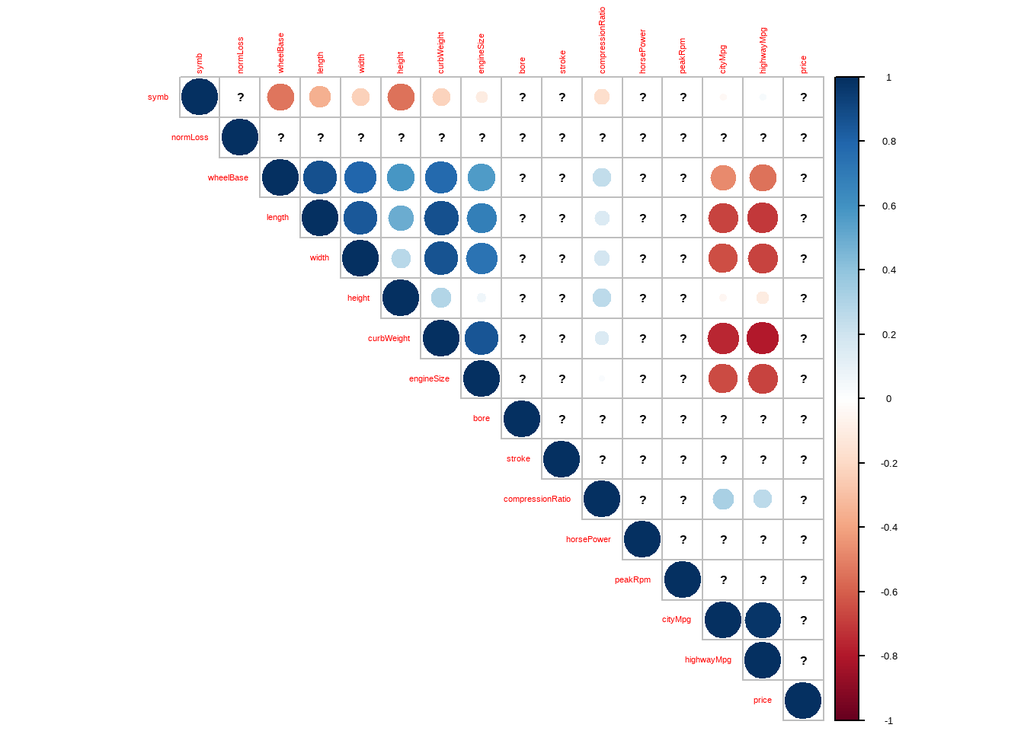

```r
library(corrplot)

# Trazar la matriz de correlacion
corrplot(dfCorrelacionMatriz, method = "circle", type = "upper", tl.cex = 0.7)
```

```r
# method = "circle" indica que se desea representar los coeficientes de correlación utilizando un gráfico de círculo.
# type = "upper" muestra solo la mitad superior de la matriz de correlación, ya que la mitad inferior es simétrica.
# tl.cex = 0.7: Controla el tamaño de las etiquetas que se muestran en la matriz de correlación
```

## 5. Cargue el conjunto de datos USJudgeRatings, del paquete de conjuntos de datos, que contiene las calificaciones de los abogados de los jueces estatales en el Tribunal Superior de EE.UU. con respecto a un conjunto de atributos.

```r
# Cargar el archivo csv USJudgeRatings
ruta <- file.path("R:/Politécnica.Nacional/2023-A/Data Mining/Deberes.Data/USJudgeRatings.csv")
dfJudge <- read.csv(ruta)

print(dfJudge)
```

```
##                  X CONT INTG DMNR DILG CFMG DECI PREP FAMI ORAL WRIT PHYS RTEN
## 1    AARONSON,L.H.  5.7  7.9  7.7  7.3  7.1  7.4  7.1  7.1  7.1  7.0  8.3  7.8
## 2   ALEXANDER,J.M.  6.8  8.9  8.8  8.5  7.8  8.1  8.0  8.0  7.8  7.9  8.5  8.7
## 3   ARMENTANO,A.J.  7.2  8.1  7.8  7.8  7.5  7.6  7.5  7.5  7.3  7.4  7.9  7.8
## 4      BERDON,R.I.  6.8  8.8  8.5  8.8  8.3  8.5  8.7  8.7  8.4  8.5  8.8  8.7
## 5     BRACKEN,J.J.  7.3  6.4  4.3  6.5  6.0  6.2  5.7  5.7  5.1  5.3  5.5  4.8
## 6       BURNS,E.B.  6.2  8.8  8.7  8.5  7.9  8.0  8.1  8.0  8.0  8.0  8.6  8.6
## 7    CALLAHAN,R.J. 10.6  9.0  8.9  8.7  8.5  8.5  8.5  8.5  8.6  8.4  9.1  9.0
## 8       COHEN,S.S.  7.0  5.9  4.9  5.1  5.4  5.9  4.8  5.1  4.7  4.9  6.8  5.0
## 9        DALY,J.J.  7.3  8.9  8.9  8.7  8.6  8.5  8.4  8.4  8.4  8.5  8.8  8.8
## 10    DANNEHY,J.F.  8.2  7.9  6.7  8.1  7.9  8.0  7.9  8.1  7.7  7.8  8.5  7.9
## 11       DEAN,H.H.  7.0  8.0  7.6  7.4  7.3  7.5  7.1  7.2  7.1  7.2  8.4  7.7
## 12     DEVITA,H.J.  6.5  8.0  7.6  7.2  7.0  7.1  6.9  7.0  7.0  7.1  6.9  7.2
## 13   DRISCOLL,P.J.  6.7  8.6  8.2  6.8  6.9  6.6  7.1  7.3  7.2  7.2  8.1  7.7
## 14     GRILLO,A.E.  7.0  7.5  6.4  6.8  6.5  7.0  6.6  6.8  6.3  6.6  6.2  6.5
```

[output cut: 29 more lines]

```r
#
```

### (a) Aplique la función prcomp() para obtener los componentes principales. Inspeccione cómo se obtiene cada variable mediante la combinación lineal de cada componente.

```r
# Excluir la 1ra columna del conjunto de datos
dfNumeros <- dfJudge[, -1]

# Aplicar la funcion prcomp()
dfComponentes <- prcomp(dfNumeros)

# Obtiene los componentes principales
componentes <- dfComponentes$x

# Inspecciona la combinacion lineal de cada variable en cada componente
for (i in 1:length(dfComponentes$rotation)) {
  # Obtiene el numero de columnas de dfComponentes$rotationy se asegura de que i sea menor o igual a ese numero
  if (i <= ncol(dfComponentes$rotation)) {
    variable <- names(dfNumeros)[i]
    combLineal <- dfComponentes$rotation[, i]

    print(paste("Variable:", variable))
    print("Combinación lineal en cada componente:")
    print(combLineal)
    print("----------------")
  }
}
```

```
## [1] "Variable: CONT"
## [1] "Combinación lineal en cada componente:"
##        CONT        INTG        DMNR        DILG        CFMG        DECI
##  0.00599117 -0.23476045 -0.34774394 -0.28678321 -0.27201855 -0.25330240
##        PREP        FAMI        ORAL        WRIT        PHYS        RTEN
## -0.30910791 -0.30510111 -0.33195277 -0.31396635 -0.27750639 -0.35932337
## [1] "----------------"
## [1] "Variable: INTG"
## [1] "Combinación lineal en cada componente:"
##         CONT         INTG         DMNR         DILG         CFMG         DECI
##  0.933248839 -0.138724061 -0.232070496  0.047953743  0.163199298  0.117624159
##         PREP         FAMI         ORAL         WRIT         PHYS         RTEN
##  0.047023458  0.014033493  0.009669279 -0.018092578  0.096014861 -0.033595756
## [1] "----------------"
## [1] "Variable: DMNR"
## [1] "Combinación lineal en cada componente:"
##        CONT        INTG        DMNR        DILG        CFMG        DECI
## -0.31985402 -0.36981582 -0.66343490  0.22433991  0.18935451  0.24920335
##        PREP        FAMI        ORAL        WRIT        PHYS        RTEN
##  0.21702209  0.26692334  0.03718715  0.11487882  0.03603598 -0.19563408
## [1] "----------------"
## [1] "Variable: DILG"
## [1] "Combinación lineal en cada componente:"
##         CONT         INTG         DMNR         DILG         CFMG         DECI
##  0.112932711  0.252211159  0.034666432  0.272806418 -0.024818035 -0.024620949
##         PREP         FAMI         ORAL         WRIT         PHYS         RTEN
##  0.191109898  0.168833090  0.007519155  0.141585317 -0.859239241 -0.152859043
## [1] "----------------"
## [1] "Variable: CFMG"
## [1] "Combinación lineal en cada componente:"
##        CONT        INTG        DMNR        DILG        CFMG        DECI
##  0.09462326  0.04590748 -0.19413671 -0.37555702 -0.47964024 -0.42029465
##        PREP        FAMI        ORAL        WRIT        PHYS        RTEN
##  0.14553660  0.47073965  0.25286574  0.29475017  0.09522754  0.02899495
## [1] "----------------"
## [1] "Variable: DECI"
## [1] "Combinación lineal en cada componente:"
##         CONT         INTG         DMNR         DILG         CFMG         DECI
## -0.002863094 -0.463156453  0.360824575 -0.563858944  0.169861226  0.368776968
##         PREP         FAMI         ORAL         WRIT         PHYS         RTEN
```

[output cut: 29 more lines]

```
## [1] "----------------"
## [1] "Variable: PHYS"
## [1] "Combinación lineal en cada componente:"
##        CONT        INTG        DMNR        DILG        CFMG        DECI
##  0.01671326 -0.15992927  0.11310307  0.09706351  0.19431559 -0.18697238
##        PREP        FAMI        ORAL        WRIT        PHYS        RTEN
## -0.34000143  0.53543928 -0.63676735  0.10601295 -0.01173895  0.24508578
## [1] "----------------"
## [1] "Variable: RTEN"
## [1] "Combinación lineal en cada componente:"
##         CONT         INTG         DMNR         DILG         CFMG         DECI
##  0.007431325 -0.006194162 -0.055818131 -0.059529611 -0.040188043 -0.045701668
##         PREP         FAMI         ORAL         WRIT         PHYS         RTEN
##  0.293499296 -0.467666232 -0.429930400  0.702784185  0.056591229  0.052358190
## [1] "----------------"
```

### (b) Cargue el paquete ggbiplot y trace los dos primeros componentes con la función ggbiplot (). Puede etiquetar cada punto con el nombre del abogado configurando el parámetro etiquetas.

```r
# Cambiar nombre a columna
dfJudge %>% rename(Nombre=X)
```

| Nombre | CONT | INTG | DMNR | DILG | CFMG | DECI | PREP | FAMI | ORAL | WRIT | PHYS | RTEN |
| --- | --- | --- | --- | --- | --- | --- | --- | --- | --- | --- | --- | --- |
| AARONSON,L.H. | 5.7 | 7.9 | 7.7 | 7.3 | 7.1 | 7.4 | 7.1 | 7.1 | 7.1 | 7.0 | 8.3 | 7.8 |
| ALEXANDER,J.M. | 6.8 | 8.9 | 8.8 | 8.5 | 7.8 | 8.1 | 8.0 | 8.0 | 7.8 | 7.9 | 8.5 | 8.7 |
| ARMENTANO,A.J. | 7.2 | 8.1 | 7.8 | 7.8 | 7.5 | 7.6 | 7.5 | 7.5 | 7.3 | 7.4 | 7.9 | 7.8 |
| BERDON,R.I. | 6.8 | 8.8 | 8.5 | 8.8 | 8.3 | 8.5 | 8.7 | 8.7 | 8.4 | 8.5 | 8.8 | 8.7 |
| BRACKEN,J.J. | 7.3 | 6.4 | 4.3 | 6.5 | 6.0 | 6.2 | 5.7 | 5.7 | 5.1 | 5.3 | 5.5 | 4.8 |
| BURNS,E.B. | 6.2 | 8.8 | 8.7 | 8.5 | 7.9 | 8.0 | 8.1 | 8.0 | 8.0 | 8.0 | 8.6 | 8.6 |
| CALLAHAN,R.J. | 10.6 | 9.0 | 8.9 | 8.7 | 8.5 | 8.5 | 8.5 | 8.5 | 8.6 | 8.4 | 9.1 | 9.0 |
| COHEN,S.S. | 7.0 | 5.9 | 4.9 | 5.1 | 5.4 | 5.9 | 4.8 | 5.1 | 4.7 | 4.9 | 6.8 | 5.0 |
| DALY,J.J. | 7.3 | 8.9 | 8.9 | 8.7 | 8.6 | 8.5 | 8.4 | 8.4 | 8.4 | 8.5 | 8.8 | 8.8 |
| DANNEHY,J.F. | 8.2 | 7.9 | 6.7 | 8.1 | 7.9 | 8.0 | 7.9 | 8.1 | 7.7 | 7.8 | 8.5 | 7.9 |

[output cut: 33 more lines]

### No se puede imprimir las etiquetas con nombres de los abogados, por lo que se procede a imprimir sin las etiquetas de nombre de abogados

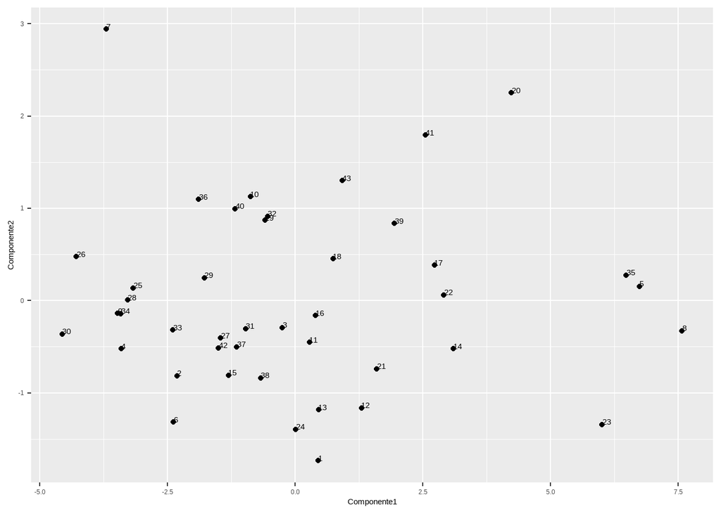

```r
library(ggplot2)

# Crear un dataframe con los componentes principales y los nombres de los abogados
df_plot <- data.frame(Componente1 = componentes[, 1], Componente2 = componentes[, 2], Abogado = rownames(dfNumeros))

# Trama de dispersión de los componentes principales
ggplot(df_plot, aes(x = Componente1, y = Componente2, label = Abogado)) +
  geom_point() +
  geom_text(hjust = 0, vjust = 0)
```